# Public Interest::Data Ethics & Practice

Michele Claibourn

2022-01-19

## Getting Started with R

Who are we wrt R?

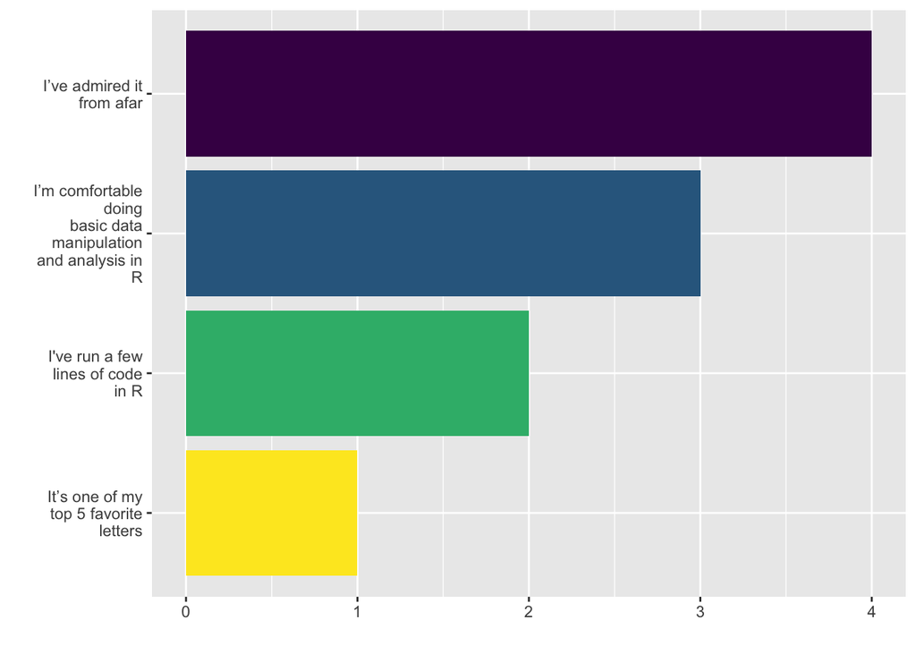

### “great frustration and much suckiness…”

[video not shown]

### R, RStudio, RStudio Cloud

[R is the computational engine; RStudio is the interface](https://moderndive.com/1-getting-started.html#r-rstudio)

[figure not shown]

RStudio Cloud is the same, but online.

### Organizing R

For any new project in R, create an R project. Projects allow RStudio to leave notes for itself (e.g., history), will always start a new R session when opened, and will always set the working directory to the Project directory. If you never have to set the working directory at the top of the script, that’s a good thing![^1]

And create a system for [organizing the objects in this project](https://martinctc.github.io/blog/rstudio-projects-and-working-directories-a-beginner%27s-guide/)!

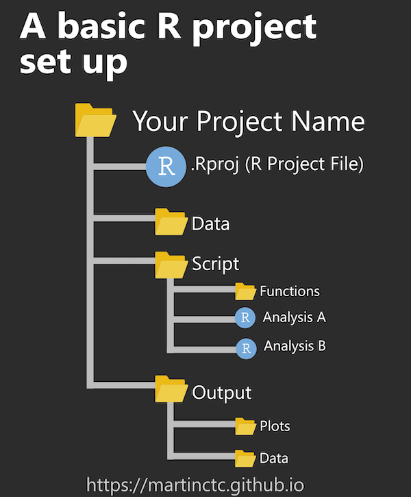

I’ll try to structure shared projects in a similar manner.

### R Packages

Functions are the “verbs” that allow us to manipulate data. Packages contain functions, and all functions belong to packages.

R comes with about 30 packages (“base R”). There are over 10,000 user-contributed packages; you can discover these packages online in Comprehensive R Archive Network ([CRAN](https://cran.r-project.org/)), with more in active development on GitHub.

To use a package, install it **once**

- You can install packages via point-and-click: Tools…Install Packages…Enter `tidyverse` (or a different package name) then click on Install.
- Or you can use this command in the console: `install.packages("tidyverse")`

RStudio Cloud allows me to set up a base project to share, so *in the beginning*, all of the packages you need should be installed in our shared space.

In each new R session, you’ll have to load the package if you want access to its functions: e.g., type `library(tidyverse)`.

## R Basics

- R is case sensitive
- Everything in R is an object (vectors, lists, matrices, **data frames**)
- `#` demarcates code comments
- `<-` is the assignment operator, how we name new objects in the R environment
- `$` is the accessor operator (or extractor), how we call named variables within an R data frame (in base R)

### Reading in data

You can import pretty much any data format into R if you know the right `command` and (package):

- CSV: `read.csv` (base R), `read_csv` (tidyverse)
- Excel: `read_excel` (readxl)
- Stata, SPSS, SAS: e.g., `read.dta` (foreign), `read_dta` (haven)
- JSON, fixed-width, TXT, DAT, shape files, etc.

Primary data types include numeric, integer, logical, and character; plus factors.

### Some initial R commands

- Examining data: `names()`, `head()`, `tail()`, `str()`, `glimpse()`
- Summarizing data: `summary()`, `table()`, `xtabs()`

## dplyr

Part of the the [`tidyverse`](https://www.tidyverse.org/), [`dplyr`](https://dplyr.tidyverse.org/) is a package for data manipulation. The package implements a *grammar* for transforming data, based on verbs/functions that define a set of common tasks.

`dplyr` functions are for `d`ata frames.

- first argument of `dplyr` functions is always a data frame
- followed by function specific arguments that detail what to do

[dplyr cheatsheet!](https://raw.githubusercontent.com/rstudio/cheatsheets/master/data-transformation.pdf)

### Some initial dplyr commands

#### $\color{blue}{\text{select()}}$ - extract $\color{blue}{\text{variables}}$

select() helpers include

- select(.data, **var1:var10**): select range of columns
- select(.data, **-c(var1, var2)**): select every column but
- select(.data, **starts_with(“string”)**): select columns that start with… (or **ends_with(“string”)**)
- select(.data, **contains(“string”)**): select columns whose names contain…

#### $\color{green}{\text{filter()}}$ - extract $\color{green}{\text{rows}}$

| Logical tests | Boolean operators for multiple conditions |
| --- | --- |
| x **<** y: less than | a **&** b: and |
| y **>=** y: greater than or equal to | a **\|** b: or |
| x **==** y: equal to | **xor(**a,b**)**: exactly or |
| x **!=** y: not equal to | **!**a: not |
| x **%in%** y: is a member of |  |
| **is.na(**x**)**: is NA |  |
| **!is.na(**x**)**: is not NA |  |

##### $\color{green}{\text{arrange()}}$ - reorder $\color{green}{\text{rows}}$

- Reverse the order (largest to smallest) with `desc()`

### Pipes!

The pipe (`%>%`) allows you to chain together functions by passing (piping) the result on the left into the first argument of the function on the right.

Less good alternatives

- Create nested functions

```r
arrange(
  select(
    filter(general, Fine > 0),
    Charge, CodeSection, CaseType, Class, Fine),
  desc(Fine))
```

- Run and save intermediate steps

```r
tmp <- filter(general, Fine > 0)
tmp <- select(tmp, Charge, CodeSection, CaseType, Class, Fine)
arrange(tmp, desc(Fine))
```

With the pipe, we call each function in sequence (read the pipe as “and then…”)

```r
general %>%
  filter(Fine > 0) %>%
  select(Charge, CodeSection, CaseType, Class, Fine) %>%
  arrange(desc(Fine))
```

Keyboard shortcut to create `%>%`

- Mac: cmd + shift + m
- Windows: ctrl + shift + m

## Let’s Play with R!

[figure not shown]

Artwork by @allison_horst

[^1]: Especially since no one seems to understand [paths and directories any more.](https://www.theverge.com/platform/amp/22684730/students-file-folder-directory-structure-education-gen-z)